# Wikipedia extracteur de tableaux

```
cree par Donatien Eneman
Nov 2018
Dans le cadre du projet du cours de developpement d'application
```

Le but de ce programme est d’extraire les tableaux wikipedia qui sont qualifie en tant que wikitable sortable. Nous avions au depart plus de 300 Urls wikipedia et le but etait de : *recuperer le plus de tableau possible* Les exporter en fichier CSV dans le dossier output/html

# Licence

```
GNU V3
```

# Preambule

Afin d’utiliser l’extracteur il faut tout d’abord installer un ??diteur de texte java (exemple Eclipse) et un JEE java.

Lors de l’installation d’eclipse, ce dernier propose directement d’installer un JEE.

# Executer

Importer le dossier :

```
wikimatrix
```

et se rendre dans la classe

```
mvnTest
```

Il faut ensuite ce rendre dans la classe `mvnTest` et l’executer, les resultats se trouveront dans le fichier `output`

Pour charger un autre fichier .txt contenant d’autres URls changer la valeur de charger

```
        File charger = new File("inputdata" + File.separator + "wikiurls.txt");
```

Pour stocker dans un autre r??pertoire changer l’attribut destination

```
        String destination = "output" + File.separator + "html" + File.separator;
```

# Maven dependances

Ajouter les d??pendances suivantes dans le fichier pom.xml qui g??re les dependances maven.

```
    <dependency>
            <groupId>junit</groupId>
            <artifactId>junit</artifactId>
            <version>4.12</version>
            <scope>test</scope>
        </dependency>
        <dependency>
            <!-- jsoup HTML parser library @ https://jsoup.org/ -->
            <groupId>org.jsoup</groupId>
            <artifactId>jsoup</artifactId>
            <version>1.11.3</version>
        </dependency>
        <dependency>
            <groupId>org.apache.commons</groupId>
            <artifactId>commons-csv</artifactId>
            <version>1.6</version>
        </dependency>
```

# Le diagramme de classe :

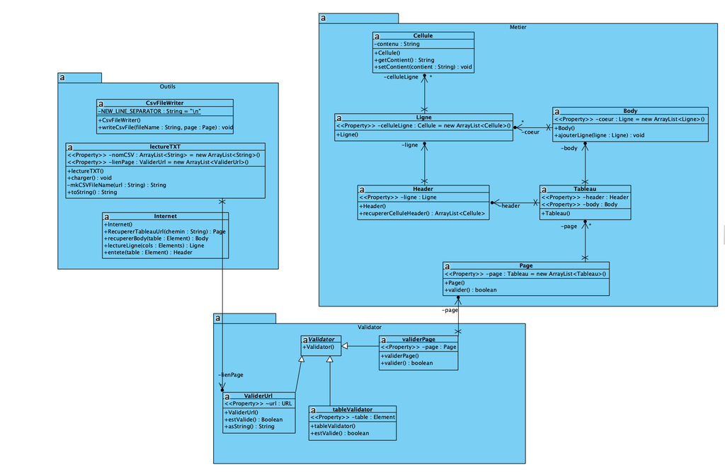

Ci dessus le diagramme de classe de cette application